# NYPD Shooting Data

Bradley Sides

04/25/2024

```r
library(readr)
library(dplyr)
library(tidyr)
library(lubridate)
```

```r
library(ggplot2)
url <- "https://data.cityofnewyork.us/api/views/833y-fsy8/rows.csv?accessType=DOWNLOAD"

file <- "NYPD_Shooting_Incident_Data_Historic.csv"
download.file(url, destfile = file, method = "curl")

dat = read_csv(file)
glimpse(dat)
```

```
## Rows: 28,562
## Columns: 21
## $ INCIDENT_KEY            <dbl> 244608249, 247542571, 84967535, 202853370, 270…
## $ OCCUR_DATE              <chr> "05/05/2022", "07/04/2022", "05/27/2012", "09/…
## $ OCCUR_TIME              <time> 00:10:00, 22:20:00, 19:35:00, 21:00:00, 21:00…
## $ BORO                    <chr> "MANHATTAN", "BRONX", "QUEENS", "BRONX", "BROO…
## $ LOC_OF_OCCUR_DESC       <chr> "INSIDE", "OUTSIDE", NA, NA, NA, NA, NA, NA, N…
## $ PRECINCT                <dbl> 14, 48, 103, 42, 83, 23, 113, 77, 48, 49, 73, …
## $ JURISDICTION_CODE       <dbl> 0, 0, 0, 0, 0, 2, 0, 0, 0, 0, 0, 0, 0, 0, 0, 0…
## $ LOC_CLASSFCTN_DESC      <chr> "COMMERCIAL", "STREET", NA, NA, NA, NA, NA, NA…
## $ LOCATION_DESC           <chr> "VIDEO STORE", "(null)", NA, NA, NA, "MULTI DW…
## $ STATISTICAL_MURDER_FLAG <lgl> TRUE, TRUE, FALSE, FALSE, FALSE, FALSE, TRUE, …
## $ PERP_AGE_GROUP          <chr> "25-44", "(null)", NA, "25-44", "25-44", NA, N…
## $ PERP_SEX                <chr> "M", "(null)", NA, "M", "M", NA, NA, NA, NA, "…
## $ PERP_RACE               <chr> "BLACK", "(null)", NA, "UNKNOWN", "BLACK", NA,…
## $ VIC_AGE_GROUP           <chr> "25-44", "18-24", "18-24", "25-44", "25-44", "…
## $ VIC_SEX                 <chr> "M", "M", "M", "M", "M", "M", "M", "M", "M", "…
## $ VIC_RACE                <chr> "BLACK", "BLACK", "BLACK", "BLACK", "BLACK", "…
## $ X_COORD_CD              <dbl> 986050, 1016802, 1048632, 1014493, 1009149, 99…
## $ Y_COORD_CD              <dbl> 214231.0, 250581.0, 198262.0, 242565.0, 190104…
## $ Latitude                <dbl> 40.75469, 40.85440, 40.71063, 40.83242, 40.688…
## $ Longitude               <dbl> -73.99350, -73.88233, -73.76777, -73.89071, -7…
## $ Lon_Lat                 <chr> "POINT (-73.9935 40.754692)", "POINT (-73.8823…
```

```r
summary(dat)
```

```
##   INCIDENT_KEY        OCCUR_DATE         OCCUR_TIME           BORO
##  Min.   :  9953245   Length:28562       Length:28562      Length:28562
##  1st Qu.: 65439914   Class :character   Class1:hms        Class :character
##  Median : 92711254   Mode  :character   Class2:difftime   Mode  :character
##  Mean   :127405824                      Mode  :numeric
##  3rd Qu.:203131993
##  Max.   :279758069
##
##  LOC_OF_OCCUR_DESC     PRECINCT     JURISDICTION_CODE LOC_CLASSFCTN_DESC
##  Length:28562       Min.   :  1.0   Min.   :0.0000    Length:28562
##  Class :character   1st Qu.: 44.0   1st Qu.:0.0000    Class :character
##  Mode  :character   Median : 67.0   Median :0.0000    Mode  :character
##                     Mean   : 65.5   Mean   :0.3219
##                     3rd Qu.: 81.0   3rd Qu.:0.0000
##                     Max.   :123.0   Max.   :2.0000
##                                     NA's   :2
##  LOCATION_DESC      STATISTICAL_MURDER_FLAG PERP_AGE_GROUP
##  Length:28562       Mode :logical           Length:28562
##  Class :character   FALSE:23036             Class :character
##  Mode  :character   TRUE :5526              Mode  :character
##
##
##
##
##    PERP_SEX          PERP_RACE         VIC_AGE_GROUP        VIC_SEX
##  Length:28562       Length:28562       Length:28562       Length:28562
##  Class :character   Class :character   Class :character   Class :character
##  Mode  :character   Mode  :character   Mode  :character   Mode  :character
##
##
##
##
##    VIC_RACE           X_COORD_CD        Y_COORD_CD        Latitude
##  Length:28562       Min.   : 914928   Min.   :125757   Min.   :40.51
##  Class :character   1st Qu.:1000068   1st Qu.:182912   1st Qu.:40.67
##  Mode  :character   Median :1007772   Median :194901   Median :40.70
##                     Mean   :1009424   Mean   :208380   Mean   :40.74
##                     3rd Qu.:1016807   3rd Qu.:239814   3rd Qu.:40.82
##                     Max.   :1066815   Max.   :271128   Max.   :40.91
##                                                        NA's   :59
##    Longitude        Lon_Lat
##  Min.   :-74.25   Length:28562
##  1st Qu.:-73.94   Class :character
##  Median :-73.92   Mode  :character
##  Mean   :-73.91
##  3rd Qu.:-73.88
##  Max.   :-73.70
##  NA's   :59
```

```r
dat <- select(dat, -c("LOC_OF_OCCUR_DESC", "JURISDICTION_CODE", "LOC_CLASSFCTN_DESC", "PERP_SEX", "PERP_RACE", "VIC_RACE", "VIC_SEX", "X_COORD_CD", "Y_COORD_CD", "Latitude", "Longitude", "Lon_Lat", "STATISTICAL_MURDER_FLAG", "INCIDENT_KEY"))



missing <- sum(is.na(dat))
missing
```

```
## [1] 24321
```

```r
dat <-dat %>% drop_na()

glimpse(dat)
```

```
## Rows: 10,210
## Columns: 7
## $ OCCUR_DATE     <chr> "05/05/2022", "07/04/2022", "07/29/2007", "11/30/2022",…
## $ OCCUR_TIME     <time> 00:10:00, 22:20:00, 04:33:00, 21:15:00, 18:26:00, 19:1…
## $ BORO           <chr> "MANHATTAN", "BRONX", "QUEENS", "BRONX", "QUEENS", "BRO…
## $ PRECINCT       <dbl> 14, 48, 113, 46, 105, 67, 42, 101, 75, 60, 83, 73, 49, …
## $ LOCATION_DESC  <chr> "VIDEO STORE", "(null)", "BAR/NIGHT CLUB", "(null)", "P…
## $ PERP_AGE_GROUP <chr> "25-44", "(null)", "UNKNOWN", "18-24", "45-64", "25-44"…
## $ VIC_AGE_GROUP  <chr> "25-44", "18-24", "25-44", "<18", "45-64", "25-44", "18…
```

```r
summary(dat)
```

```
##   OCCUR_DATE         OCCUR_TIME           BORO              PRECINCT
##  Length:10210       Length:10210      Length:10210       Min.   :  1.0
##  Class :character   Class1:hms        Class :character   1st Qu.: 43.0
##  Mode  :character   Class2:difftime   Mode  :character   Median : 67.0
##                     Mode  :numeric                       Mean   : 64.5
##                                                          3rd Qu.: 81.0
##                                                          Max.   :123.0
##  LOCATION_DESC      PERP_AGE_GROUP     VIC_AGE_GROUP
##  Length:10210       Length:10210       Length:10210
##  Class :character   Class :character   Class :character
##  Mode  :character   Mode  :character   Mode  :character
##
##
##
```

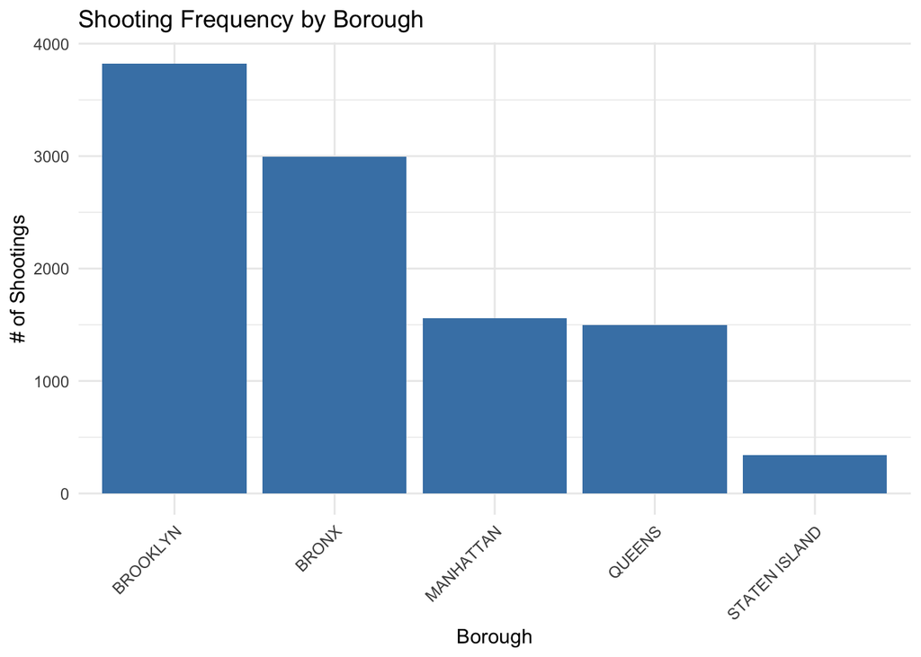

```r
# Boro Analysis
boro_counts <- dat %>%
  count(BORO, name = "Shootings") %>%
  arrange(desc(Shootings))

ggplot(boro_counts, aes(x = reorder(BORO, -Shootings), y = Shootings)) + geom_bar(stat = "identity", fill = "steelblue") + labs(x = "Borough", y = "# of Shootings", title="Shooting Frequency by Borough") + theme_minimal() + theme(axis.text.x = element_text(angle = 45, hjust = 1))
```

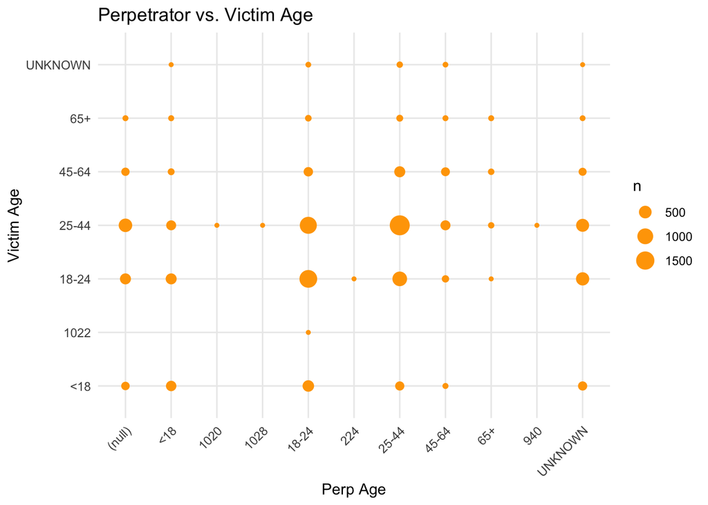

```r
# Victim age vs Perp age

age_group_counts <- dat %>%
  count(PERP_AGE_GROUP, VIC_AGE_GROUP)

ggplot(age_group_counts, aes(x = PERP_AGE_GROUP, y = VIC_AGE_GROUP)) +
  geom_count(aes(size = n), color = "orange") +
  labs(x = "Perp Age", y = "Victim Age", title = "Perpetrator vs. Victim Age") +
  theme_minimal() +
  theme(axis.text.x = element_text(angle = 45, hjust = 1))
```

### Analysis: Perpetrators tend to be around the same age as their victims, with the biggest concentration of shootins being inside the 18-24 and 25-44 age range, which does make sense. The 18-24 age range is much smaller though, meaning that a 6-year range of ages commits nearly the same amount of shootings as a 20-year age range, which is significant. Perp and victim ages both taper off in all directions.

### Conclusion and Bias Statement: With this data, we are able to look into shooting frequency across the New York City boroughs as well as the ages of both perpetrators and victims. We are looking at raw numbers, so bias should be minimized, however some important factors to consider when reading this data are that the shootings by Borough are total numbers, not adjusted for population, which could be misleading. On top of this, there are many factors that contribute to violence in areas that can be overlooked when only looking at numbers.